# VGT JN fixations

Mariya Cherkasova

Jan 21, 2020

Load variables, data cleaning

Inspect DVs

```r
summary(fix_choice_data$logDT)
```

```
##    Min. 1st Qu.  Median    Mean 3rd Qu.    Max.
##   0.000   5.380   6.146   5.446   6.551   9.802
```

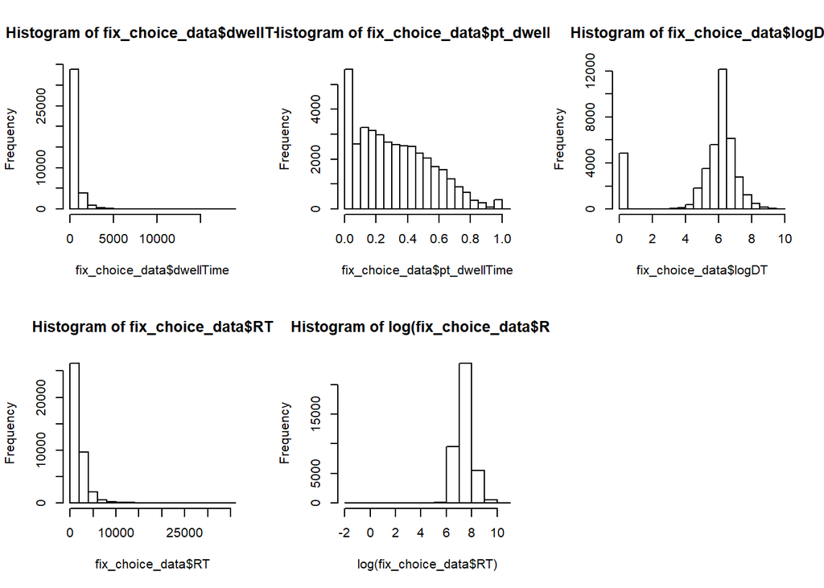

```r
par(mfrow=c(2,3))
hist(fix_choice_data$dwellTime)
hist(fix_choice_data$pt_dwellTime)
hist(fix_choice_data$logDT)
hist(fix_choice_data$RT)
hist(log(fix_choice_data$RT))
```

# Isometric log ratio transformations for the dwell time and % dwell time data My reasoning is that because ILR represents a datapoint’s coordinate in a k-1 dimensional space, k needs to be 2 for this to be a meaningful analysis unit. So ILR needs to be performed on p and mag+fix or on m and p+fix or on fix and p+m (z, zz and zzz, respectively). ILRs based on dwell times vs. % dwell times are essentially the same.

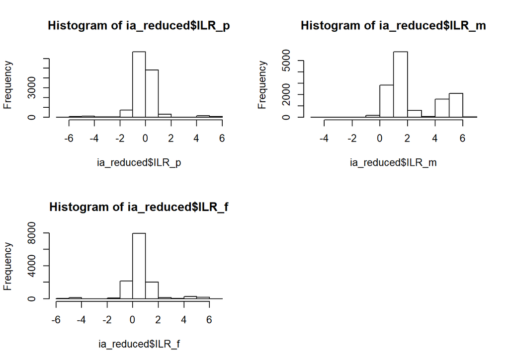

```r
par(mfrow=c(2,2))
hist(ia_reduced$ILR_p)
hist(ia_reduced$ILR_m)
hist(ia_reduced$ILR_f)
```

# GLMs on log dwell time and % dwell time

```r
ml = lmer(pt_dwellTime ~ Cues*ia + order + logRT + (ia|subj), data=fix_choice_data,control = lmerControl(optimizer="bobyqa"))
summary(ml)
```

```
## Linear mixed model fit by REML. t-tests use Satterthwaite's method [
## lmerModLmerTest]
## Formula: pt_dwellTime ~ Cues * ia + order + logRT + (ia | subj)
##    Data: fix_choice_data
## Control: lmerControl(optimizer = "bobyqa")
##
## REML criterion at convergence: -43967.7
##
## Scaled residuals:
##     Min      1Q  Median      3Q     Max
## -5.4139 -0.5462 -0.0379  0.5624  5.9628
##
## Random effects:
##  Groups   Name        Variance Std.Dev. Corr
##  subj     (Intercept) 0.01236  0.1112
##           iamag       0.01771  0.1331   -0.91
##           iaprob      0.04638  0.2154   -0.95  0.76
##  Residual             0.01851  0.1360
## Number of obs: 39300, groups:  subj, 131
##
## Fixed effects:
##               Estimate Std. Error         df t value Pr(>|t|)
## (Intercept)  2.907e-01  1.725e-02  2.844e+02  16.849  < 2e-16 ***
## Cues         3.051e-02  1.959e-02  1.285e+02   1.558  0.12179
## iamag       -2.070e-01  1.694e-02  1.290e+02 -12.218  < 2e-16 ***
## iaprob       2.237e-01  2.724e-02  1.290e+02   8.213 1.95e-13 ***
## order       -1.468e-03  2.570e-03  1.287e+02  -0.571  0.56888
## logRT        3.491e-03  1.343e-03  4.741e+03   2.599  0.00937 **
## Cues:iamag  -2.609e-02  2.351e-02  1.290e+02  -1.110  0.26918
## Cues:iaprob -7.670e-02  3.781e-02  1.290e+02  -2.029  0.04457 *
## ---
## Signif. codes:  0 '***' 0.001 '**' 0.01 '*' 0.05 '.' 0.1 ' ' 1
##
## Correlation of Fixed Effects:
##             (Intr) Cues   iamag  iaprob order  logRT  Cus:mg
## Cues        -0.588
## iamag       -0.743  0.654
## iaprob      -0.775  0.683  0.758
## order        0.028  0.009  0.000  0.000
## logRT       -0.575 -0.002  0.000  0.000 -0.059
## Cues:iamag   0.535 -0.908 -0.720 -0.546  0.000  0.000
## Cues:iaprob  0.559 -0.948 -0.546 -0.720  0.000  0.000  0.758
```

```r
ml1 = lmer(logDT ~ Cues*ia + order+ logRT + (ia|subj), data=fix_choice_data, control = lmerControl(optimizer="bobyqa"))
summary(ml1)
```

```
## Linear mixed model fit by REML. t-tests use Satterthwaite's method [
## lmerModLmerTest]
## Formula: logDT ~ Cues * ia + order + logRT + (ia | subj)
##    Data: fix_choice_data
## Control: lmerControl(optimizer = "bobyqa")
##
## REML criterion at convergence: 142173.8
##
## Scaled residuals:
##     Min      1Q  Median      3Q     Max
## -5.7952 -0.1566  0.1033  0.3909  5.6230
##
## Random effects:
##  Groups   Name        Variance Std.Dev. Corr
##  subj     (Intercept) 0.6587   0.8116
##           iamag       2.3487   1.5325   -0.41
##           iaprob      1.0380   1.0188   -0.86  0.45
##  Residual             2.1041   1.4506
## Number of obs: 39300, groups:  subj, 131
##
## Fixed effects:
##               Estimate Std. Error         df t value Pr(>|t|)
## (Intercept) -1.139e+00  1.541e-01  6.103e+02  -7.386 4.98e-13 ***
## Cues         2.730e-01  1.443e-01  1.288e+02   1.892   0.0607 .
## iamag       -2.095e+00  1.948e-01  1.290e+02 -10.753  < 2e-16 ***
## iaprob       7.170e-01  1.309e-01  1.290e+02   5.476 2.19e-07 ***
## order        3.192e-02  7.578e-02  1.281e+02   0.421   0.6743
## logRT        9.360e-01  1.541e-02  3.462e+04  60.734  < 2e-16 ***
## Cues:iamag   7.690e-02  2.704e-01  1.290e+02   0.284   0.7765
## Cues:iaprob -2.268e-01  1.817e-01  1.290e+02  -1.248   0.2143
## ---
## Signif. codes:  0 '***' 0.001 '**' 0.01 '*' 0.05 '.' 0.1 ' ' 1
##
## Correlation of Fixed Effects:
##             (Intr) Cues   iamag  iaprob order  logRT  Cus:mg
## Cues        -0.484
## iamag       -0.278  0.297
## iaprob      -0.573  0.612  0.449
## order       -0.002  0.036  0.000  0.000
## logRT       -0.739 -0.003  0.000  0.000 -0.023
## Cues:iamag   0.200 -0.413 -0.720 -0.324  0.000  0.000
## Cues:iaprob  0.413 -0.850 -0.324 -0.720  0.000  0.000  0.449
```

```r
emmip(ml1, ia ~ Cues, cov.reduce=FALSE)
```

```
## Note: D.f. calculations have been disabled because the number of observations exceeds 3000.
## To enable adjustments, set emm_options(pbkrtest.limit = 39300) or larger,
## but be warned that this may result in large computation time and memory use.
```

```
## Note: D.f. calculations have been disabled because the number of observations exceeds 3000.
## To enable adjustments, set emm_options(lmerTest.limit = 39300) or larger,
## but be warned that this may result in large computation time and memory use.
```

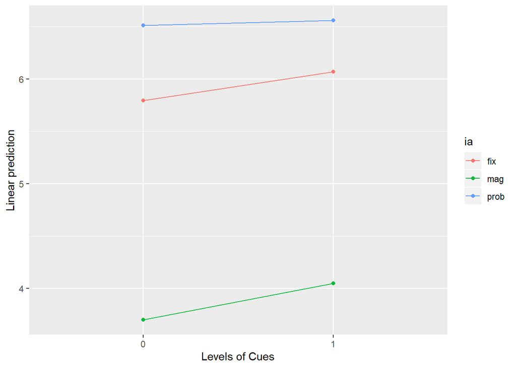

```r
#ml2 <- betareg(pt_dwellTime ~ Cues*IAnum + order + (IAnum|subj), data = data)
#ml2_est <- tidy(ml2) #beta regression is not ideal b/c there are some 0s in the response var and it's hard to justify modifying the data
```

# GLMs on ILRs

```r
ml <- lmer(ILR_p ~ Cues + order + logRT + (1|subj), data=ia_reduced, control = lmerControl(optimizer="bobyqa"))
summary(ml)
```

```
## Linear mixed model fit by REML. t-tests use Satterthwaite's method [
## lmerModLmerTest]
## Formula: ILR_p ~ Cues + order + logRT + (1 | subj)
##    Data: ia_reduced
## Control: lmerControl(optimizer = "bobyqa")
##
## REML criterion at convergence: 32556.9
##
## Scaled residuals:
##     Min      1Q  Median      3Q     Max
## -8.6587 -0.2900 -0.0092  0.2916  7.5695
##
## Random effects:
##  Groups   Name        Variance Std.Dev.
##  subj     (Intercept) 0.3391   0.5823
##  Residual             0.6751   0.8216
## Number of obs: 13100, groups:  subj, 131
##
## Fixed effects:
##               Estimate Std. Error         df t value Pr(>|t|)
## (Intercept)  4.890e+00  1.346e-01  1.251e+03  36.321   <2e-16 ***
## Cues         1.773e-01  1.031e-01  1.280e+02   1.720   0.0878 .
## order       -3.467e-02  1.030e-01  1.281e+02  -0.337   0.7370
## logRT       -6.891e-01  1.521e-02  1.309e+04 -45.315   <2e-16 ***
## ---
## Signif. codes:  0 '***' 0.001 '**' 0.01 '*' 0.05 '.' 0.1 ' ' 1
##
## Correlation of Fixed Effects:
##       (Intr) Cues   order
## Cues  -0.394
## order -0.016  0.069
## logRT -0.834 -0.004 -0.017
```

```r
ml1 <- lmer(ILR_m ~ Cues + order + logRT+ (1|subj), data=ia_reduced, control = lmerControl(optimizer="bobyqa"))
summary(ml1)
```

```
## Linear mixed model fit by REML. t-tests use Satterthwaite's method [
## lmerModLmerTest]
## Formula: ILR_m ~ Cues + order + logRT + (1 | subj)
##    Data: ia_reduced
## Control: lmerControl(optimizer = "bobyqa")
##
## REML criterion at convergence: 47641.5
##
## Scaled residuals:
##     Min      1Q  Median      3Q     Max
## -5.7908 -0.6454 -0.1892  0.4638  3.4795
##
## Random effects:
##  Groups   Name        Variance Std.Dev.
##  subj     (Intercept) 0.9858   0.9929
##  Residual             2.1378   1.4621
## Number of obs: 13100, groups:  subj, 131
##
## Fixed effects:
##               Estimate Std. Error         df t value Pr(>|t|)
## (Intercept)  5.651e+00  2.365e-01  1.381e+03  23.892   <2e-16 ***
## Cues        -1.928e-01  1.759e-01  1.280e+02  -1.096    0.275
## order        1.955e-01  1.758e-01  1.280e+02   1.112    0.268
## logRT       -4.344e-01  2.705e-02  1.308e+04 -16.061   <2e-16 ***
## ---
## Signif. codes:  0 '***' 0.001 '**' 0.01 '*' 0.05 '.' 0.1 ' ' 1
##
## Correlation of Fixed Effects:
##       (Intr) Cues   order
## Cues  -0.383
## order -0.015  0.069
## logRT -0.845 -0.004 -0.017
```

```r
ml2 <- lmer(ILR_f ~ Cues + order + logRT+ (1|subj), data=ia_reduced, control = lmerControl(optimizer="bobyqa"))
summary(ml2)
```

```
## Linear mixed model fit by REML. t-tests use Satterthwaite's method [
## lmerModLmerTest]
## Formula: ILR_f ~ Cues + order + logRT + (1 | subj)
##    Data: ia_reduced
## Control: lmerControl(optimizer = "bobyqa")
##
## REML criterion at convergence: 35884.9
##
## Scaled residuals:
##     Min      1Q  Median      3Q     Max
## -7.0022 -0.2737 -0.0378  0.1294  7.4710
##
## Random effects:
##  Groups   Name        Variance Std.Dev.
##  subj     (Intercept) 0.3788   0.6154
##  Residual             0.8716   0.9336
## Number of obs: 13100, groups:  subj, 131
##
## Fixed effects:
##               Estimate Std. Error         df t value Pr(>|t|)
## (Intercept) -5.323e+00  1.498e-01  1.479e+03 -35.542   <2e-16 ***
## Cues        -1.472e-01  1.091e-01  1.280e+02  -1.349    0.180
## order       -5.627e-02  1.090e-01  1.281e+02  -0.516    0.607
## logRT        8.099e-01  1.726e-02  1.307e+04  46.918   <2e-16 ***
## ---
## Signif. codes:  0 '***' 0.001 '**' 0.01 '*' 0.05 '.' 0.1 ' ' 1
##
## Correlation of Fixed Effects:
##       (Intr) Cues   order
## Cues  -0.375
## order -0.014  0.069
## logRT -0.851 -0.004 -0.018
```

# Does gaze fixation on different regions predict riskier choice?

Including RT in these models since RT is likely related to both decision difficulty and deliberation

# Relationships between predictors

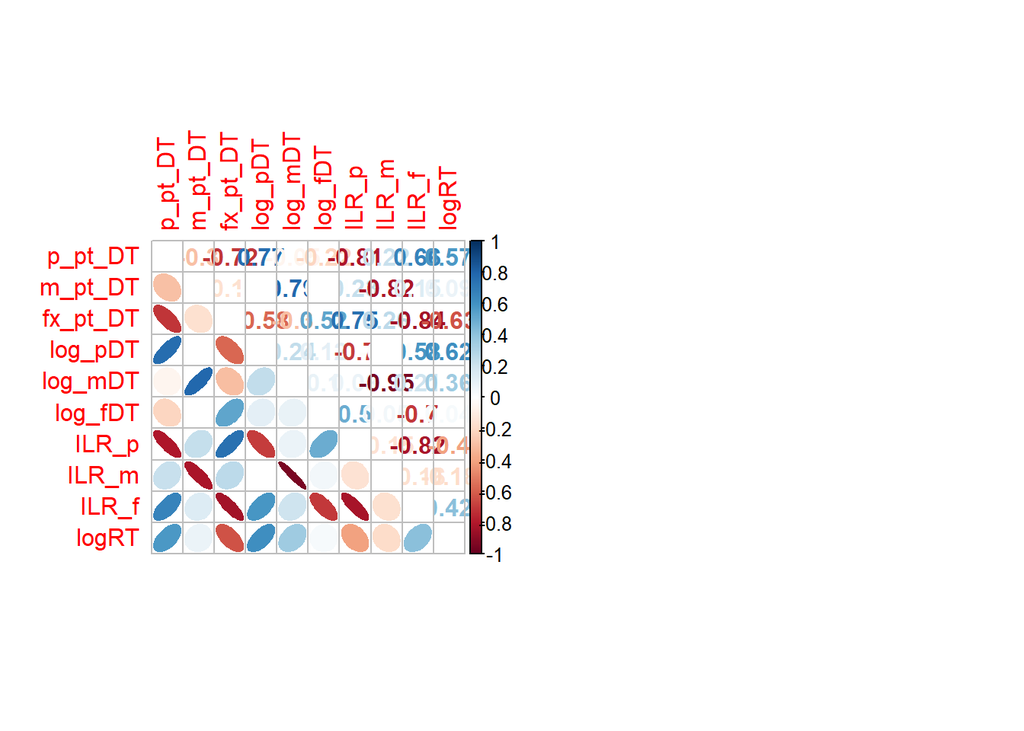

```r
cordf <- iareduced_choice %>%
  select(p_pt_DT,m_pt_DT,fx_pt_DT, log_pDT,log_mDT,log_fDT,ILR_p, ILR_m, ILR_f, logRT)

cormat <- rcorr(as.matrix(cordf)) #correlations with sex
r_mat <- cormat[["r"]]
p_mat <- cormat[["P"]]

par(mfrow=c(1,2))
corrplot.mixed(r_mat, lower = "ellipse", upper = "number",tl.pos = "lt", p.mat = p_mat, sig.level = 0.05,insig = "blank")
par(mfrow=c(2,3))
```

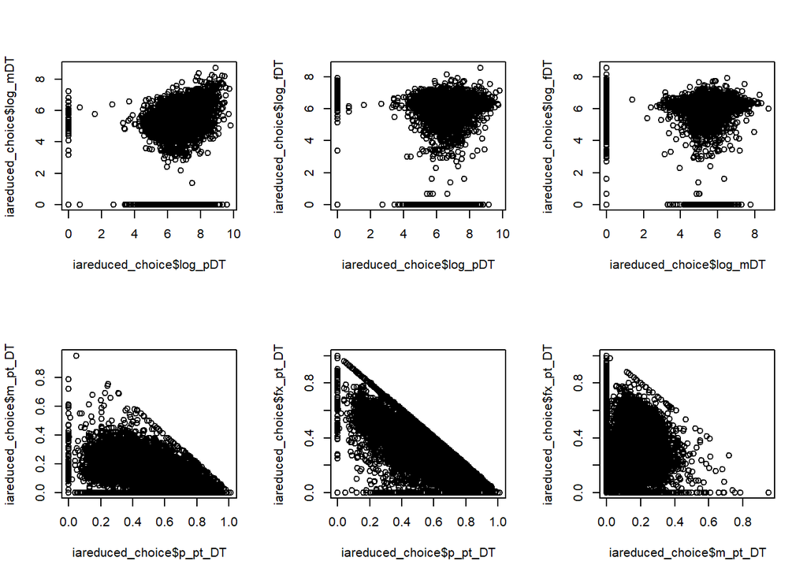

```r
plot(iareduced_choice$log_pDT,iareduced_choice$log_mDT )
plot(iareduced_choice$log_pDT,iareduced_choice$log_fDT )
plot(iareduced_choice$log_mDT,iareduced_choice$log_fDT )
plot(iareduced_choice$p_pt_DT,iareduced_choice$m_pt_DT )
plot(iareduced_choice$p_pt_DT,iareduced_choice$fx_pt_DT )
plot(iareduced_choice$m_pt_DT,iareduced_choice$fx_pt_DT )
```

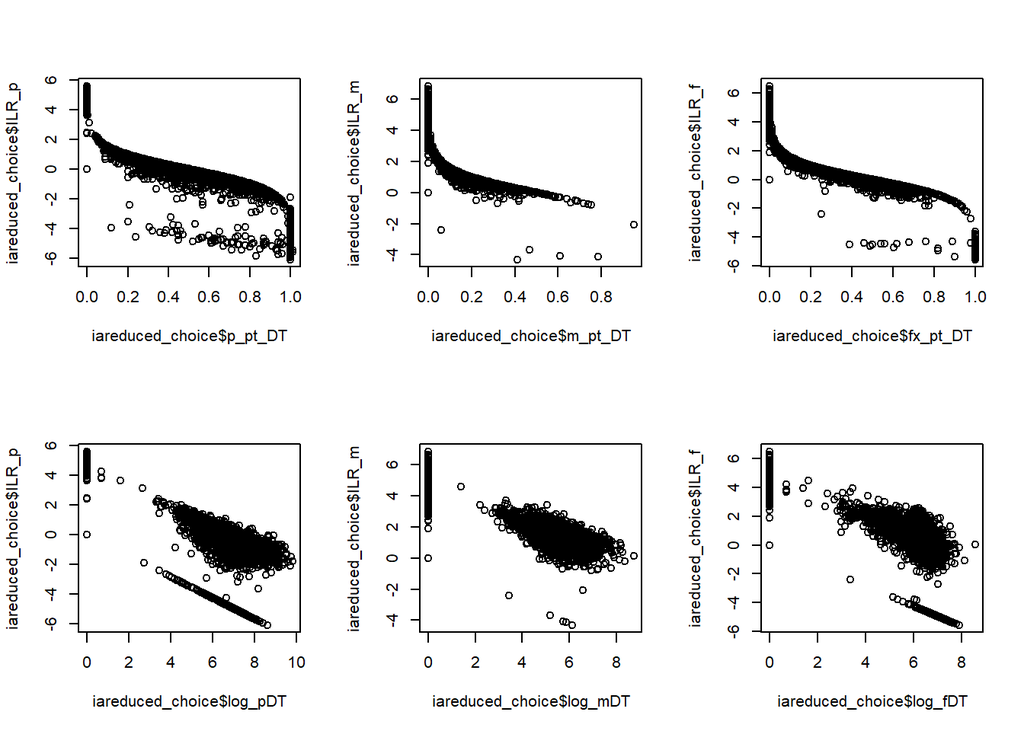

```r
par(mfrow=c(2,3))
plot(iareduced_choice$p_pt_DT,iareduced_choice$ILR_p )
plot(iareduced_choice$m_pt_DT,iareduced_choice$ILR_m )
plot(iareduced_choice$fx_pt_DT,iareduced_choice$ILR_f )
plot(iareduced_choice$log_pDT,iareduced_choice$ILR_p )
plot(iareduced_choice$log_mDT,iareduced_choice$ILR_m )
plot(iareduced_choice$log_fDT,iareduced_choice$ILR_f )
```

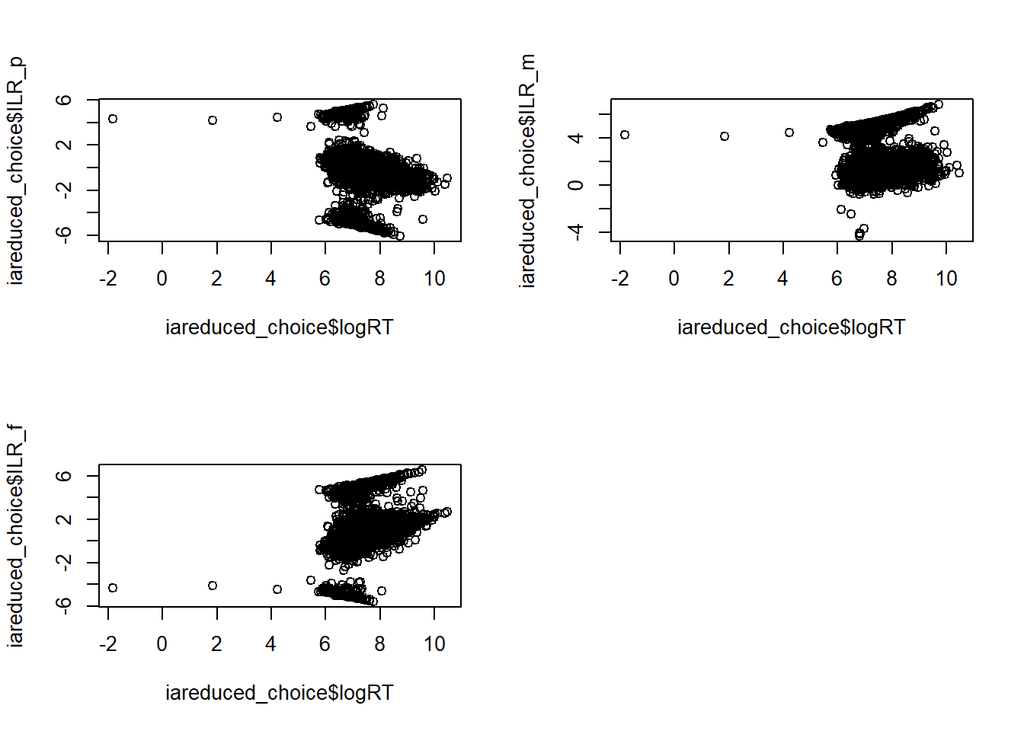

```r
par(mfrow=c(2,2))
plot(iareduced_choice$logRT,iareduced_choice$ILR_p )
plot(iareduced_choice$logRT,iareduced_choice$ILR_m )
plot(iareduced_choice$logRT,iareduced_choice$ILR_f )
```

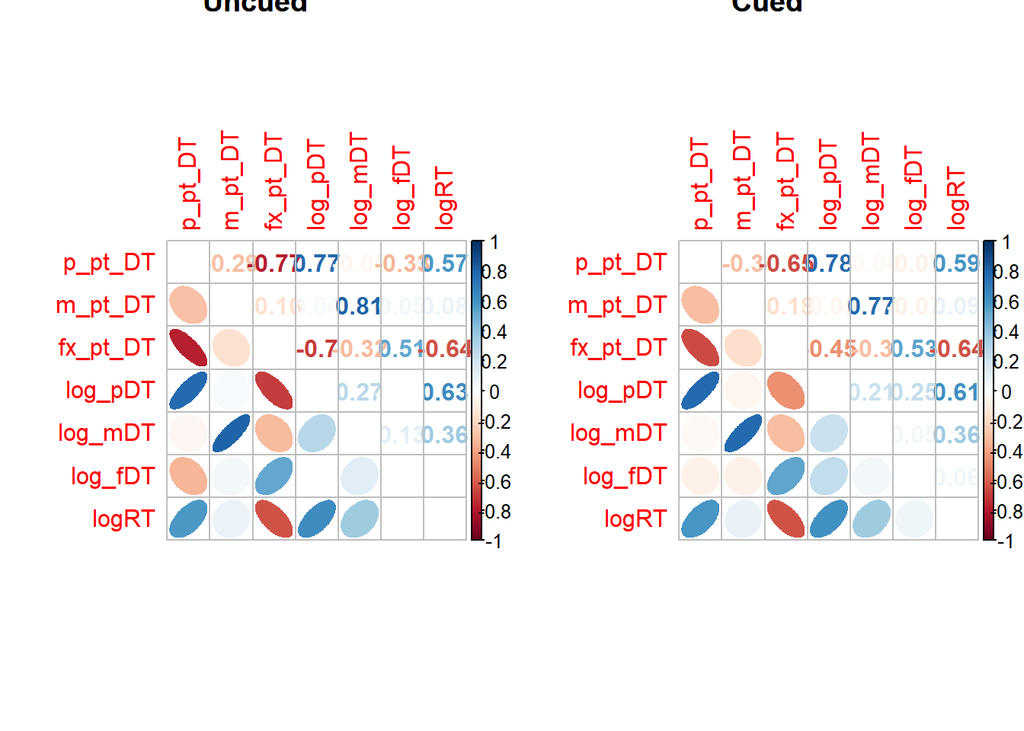

```r
cordf_uc <- iareduced_choice %>%
  filter(Cues==0) %>%
  select(p_pt_DT,m_pt_DT,fx_pt_DT, log_pDT,log_mDT,log_fDT,logRT)

cordf_c <- iareduced_choice %>%
  filter(Cues==1) %>%
  select(p_pt_DT,m_pt_DT,fx_pt_DT, log_pDT,log_mDT,log_fDT,logRT)


cormat_uc <- rcorr(as.matrix(cordf_uc)) #correlations with sex
r_mat_uc <- cormat_uc[["r"]]
p_mat_uc <- cormat_uc[["P"]]

cormat_c <- rcorr(as.matrix(cordf_c)) #correlations with sex
r_mat_c <- cormat_c[["r"]]
p_mat_c <- cormat_c[["P"]]

par(mfrow=c(1,2))
corrplot.mixed(r_mat_uc, lower = "ellipse", upper = "number",tl.pos = "lt", p.mat = p_mat_uc, sig.level = 0.05,insig = "blank", title="Uncued")
corrplot.mixed(r_mat_c, lower = "ellipse", upper = "number",tl.pos = "lt", p.mat = p_mat_c, sig.level = 0.05,insig = "blank", title="Cued")
```

# Dwell time and % dwell time as predictors

Lower probabilitie (more difficult decisions) are associated with more dwelling on probability information. Overall, when people spend a long time deliberating a choice, they spend more time looking at probabilities and magnitudes and proportionally more time looking at probabilities. When they spend little time deliberating, they proportionately look more at fixations.

```r
# predict fixations on prpbabilities and RTs from prospect probability

ml <- lmer(log_pDT ~ hiprob + (1|subj), data=iareduced_choice, control = lmerControl(optimizer="bobyqa"))
summary(ml)
```

```
## Linear mixed model fit by REML. t-tests use Satterthwaite's method [
## lmerModLmerTest]
## Formula: log_pDT ~ hiprob + (1 | subj)
##    Data: iareduced_choice
## Control: lmerControl(optimizer = "bobyqa")
##
## REML criterion at convergence: 40116.8
##
## Scaled residuals:
##     Min      1Q  Median      3Q     Max
## -6.6619 -0.3000  0.0666  0.4500  4.7326
##
## Random effects:
##  Groups   Name        Variance Std.Dev.
##  subj     (Intercept) 0.5545   0.7446
##  Residual             1.2040   1.0973
## Number of obs: 13100, groups:  subj, 131
##
## Fixed effects:
##               Estimate Std. Error         df t value Pr(>|t|)
## (Intercept)     7.8845     0.1091   957.0818   72.23   <2e-16 ***
## hiprob         -1.9910     0.1281 12968.0003  -15.54   <2e-16 ***
## ---
## Signif. codes:  0 '***' 0.001 '**' 0.01 '*' 0.05 '.' 0.1 ' ' 1
##
## Correlation of Fixed Effects:
##        (Intr)
## hiprob -0.798
```

```r
ml2 <- lmer(ILR_p ~ hiprob + (1|subj), data=iareduced_choice, control = lmerControl(optimizer="bobyqa"))
summary(ml2)
```

```
## Linear mixed model fit by REML. t-tests use Satterthwaite's method [
## lmerModLmerTest]
## Formula: ILR_p ~ hiprob + (1 | subj)
##    Data: iareduced_choice
## Control: lmerControl(optimizer = "bobyqa")
##
## REML criterion at convergence: 34315.2
##
## Scaled residuals:
##     Min      1Q  Median      3Q     Max
## -8.0071 -0.3668 -0.0051  0.3411  6.6583
##
## Random effects:
##  Groups   Name        Variance Std.Dev.
##  subj     (Intercept) 0.4305   0.6561
##  Residual             0.7717   0.8785
## Number of obs: 13100, groups:  subj, 131
##
## Fixed effects:
##               Estimate Std. Error         df t value Pr(>|t|)
## (Intercept) -9.554e-01  9.061e-02  7.667e+02  -10.54   <2e-16 ***
## hiprob       1.230e+00  1.026e-01  1.297e+04   12.00   <2e-16 ***
## ---
## Signif. codes:  0 '***' 0.001 '**' 0.01 '*' 0.05 '.' 0.1 ' ' 1
##
## Correlation of Fixed Effects:
##        (Intr)
## hiprob -0.770
```

```r
ml3 <- lmer(logRT ~ hiprob + (1|subj), data=iareduced_choice, control = lmerControl(optimizer="bobyqa"))
summary(ml3)
```

```
## Linear mixed model fit by REML. t-tests use Satterthwaite's method [
## lmerModLmerTest]
## Formula: logRT ~ hiprob + (1 | subj)
##    Data: iareduced_choice
## Control: lmerControl(optimizer = "bobyqa")
##
## REML criterion at convergence: 17250.9
##
## Scaled residuals:
##      Min       1Q   Median       3Q      Max
## -20.3566  -0.6481  -0.0786   0.5648   7.1102
##
## Random effects:
##  Groups   Name        Variance Std.Dev.
##  subj     (Intercept) 0.1448   0.3806
##  Residual             0.2093   0.4575
## Number of obs: 13100, groups:  subj, 131
##
## Fixed effects:
##               Estimate Std. Error         df t value Pr(>|t|)
## (Intercept)  8.434e+00  4.940e-02  6.073e+02  170.72   <2e-16 ***
## hiprob      -1.518e+00  5.341e-02  1.297e+04  -28.42   <2e-16 ***
## ---
## Signif. codes:  0 '***' 0.001 '**' 0.01 '*' 0.05 '.' 0.1 ' ' 1
##
## Correlation of Fixed Effects:
##        (Intr)
## hiprob -0.735
```

```r
# could longer fixation DTs in cued participants indicate post-reinforcement pauses? Predict fixation dwell times from won amounts in cued versus uncued participants

iareduced_choice$winsize <- ifelse(iareduced_choice$won==1 & iareduced_choice$hiPchoice==1, iareduced_choice$lomag, ifelse(iareduced_choice$won==1 & iareduced_choice$hiPchoice==0, iareduced_choice$himag, 0))

iareduced_choice$priorwin <- c(0,iareduced_choice$won[1:13099])
iareduced_choice$priorwinsize <- c(0,iareduced_choice$winsize[1:13099])

ml <- lmer(log_fDT ~ cues_factor*priorwin + (priorwin|subj), data=iareduced_choice, control = lmerControl(optimizer="bobyqa"))
summary(ml)
```

```
## Linear mixed model fit by REML. t-tests use Satterthwaite's method [
## lmerModLmerTest]
## Formula: log_fDT ~ cues_factor * priorwin + (priorwin | subj)
##    Data: iareduced_choice
## Control: lmerControl(optimizer = "bobyqa")
##
## REML criterion at convergence: 41761.9
##
## Scaled residuals:
##     Min      1Q  Median      3Q     Max
## -5.6273 -0.0436  0.0834  0.2771  5.2213
##
## Random effects:
##  Groups   Name        Variance Std.Dev. Corr
##  subj     (Intercept) 0.56280  0.7502
##           priorwin    0.02634  0.1623   -0.14
##  Residual             1.36082  1.1665
## Number of obs: 13100, groups:  subj, 131
##
## Fixed effects:
##                             Estimate Std. Error        df t value Pr(>|t|)
## (Intercept)                  6.10125    0.09354 129.36411  65.223   <2e-16
## cues_factoruncued           -0.31618    0.13498 129.68981  -2.342   0.0207
## priorwin                    -0.05338    0.03488 127.67837  -1.531   0.1283
## cues_factoruncued:priorwin   0.04901    0.05040 128.67315   0.973   0.3326
##
## (Intercept)                ***
## cues_factoruncued          *
## priorwin
## cues_factoruncued:priorwin
## ---
## Signif. codes:  0 '***' 0.001 '**' 0.01 '*' 0.05 '.' 0.1 ' ' 1
##
## Correlation of Fixed Effects:
##             (Intr) cs_fct prirwn
## cus_fctrncd -0.693
## priorwin    -0.221  0.153
## cs_fctrncd:  0.153 -0.224 -0.692
```

```r
#emmip(ml, cues_factor ~ priorwin, cov.reduce=FALSE)

ml2 <- lmer(logRT ~ cues_factor*priorwin + (priorwin|subj), data=iareduced_choice, control = lmerControl(optimizer="bobyqa"))
summary(ml2)
```

```
## Linear mixed model fit by REML. t-tests use Satterthwaite's method [
## lmerModLmerTest]
## Formula: logRT ~ cues_factor * priorwin + (priorwin | subj)
##    Data: iareduced_choice
## Control: lmerControl(optimizer = "bobyqa")
##
## REML criterion at convergence: 18018.3
##
## Scaled residuals:
##      Min       1Q   Median       3Q      Max
## -19.3863  -0.6641  -0.0813   0.5694   6.7481
##
## Random effects:
##  Groups   Name        Variance Std.Dev. Corr
##  subj     (Intercept) 0.148479 0.38533
##           priorwin    0.004494 0.06704  -0.14
##  Residual             0.220955 0.47006
## Number of obs: 13100, groups:  subj, 131
##
## Fixed effects:
##                             Estimate Std. Error        df t value Pr(>|t|)
## (Intercept)                  7.38766    0.04754 129.03193 155.383  < 2e-16
## cues_factoruncued           -0.01249    0.06859 129.23654  -0.182  0.85582
## priorwin                     0.04185    0.01417 129.01653   2.954  0.00373
## cues_factoruncued:priorwin  -0.01484    0.02047 130.00698  -0.725  0.46973
##
## (Intercept)                ***
## cues_factoruncued
## priorwin                   **
## cues_factoruncued:priorwin
## ---
## Signif. codes:  0 '***' 0.001 '**' 0.01 '*' 0.05 '.' 0.1 ' ' 1
##
## Correlation of Fixed Effects:
##             (Intr) cs_fct prirwn
## cus_fctrncd -0.693
## priorwin    -0.196  0.136
## cs_fctrncd:  0.135 -0.198 -0.692
```

```r
#emmip(ml2, cues_factor ~ priorwin, cov.reduce=FALSE)

ml3 <- lmer(log_fDT ~ cues_factor*priorwinsize + (1|subj), data=iareduced_choice, control = lmerControl(optimizer="bobyqa"))
summary(ml3)
```

```
## Linear mixed model fit by REML. t-tests use Satterthwaite's method [
## lmerModLmerTest]
## Formula: log_fDT ~ cues_factor * priorwinsize + (1 | subj)
##    Data: iareduced_choice
## Control: lmerControl(optimizer = "bobyqa")
##
## REML criterion at convergence: 41778.7
##
## Scaled residuals:
##     Min      1Q  Median      3Q     Max
## -5.6421 -0.0417  0.0849  0.2783  5.1907
##
## Random effects:
##  Groups   Name        Variance Std.Dev.
##  subj     (Intercept) 0.5534   0.7439
##  Residual             1.3672   1.1693
## Number of obs: 13100, groups:  subj, 131
##
## Fixed effects:
##                                  Estimate Std. Error         df t value
## (Intercept)                     6.089e+00  9.223e-02  1.342e+02  66.017
## cues_factoruncued              -3.111e-01  1.330e-01  1.343e+02  -2.339
## priorwinsize                   -1.208e-02  8.532e-03  1.297e+04  -1.416
## cues_factoruncued:priorwinsize  1.416e-02  1.252e-02  1.297e+04   1.131
##                                Pr(>|t|)
## (Intercept)                      <2e-16 ***
## cues_factoruncued                0.0208 *
## priorwinsize                     0.1567
## cues_factoruncued:priorwinsize   0.2580
## ---
## Signif. codes:  0 '***' 0.001 '**' 0.01 '*' 0.05 '.' 0.1 ' ' 1
##
## Correlation of Fixed Effects:
##             (Intr) cs_fct prrwns
## cus_fctrncd -0.693
## priorwinsiz -0.140  0.097
## cs_fctrncd:  0.096 -0.142 -0.682
```

```r
#emmip(ml3, cues_factor ~ priorwinsize, cov.reduce=FALSE)

ml4 <- lmer(logRT ~ cues_factor*priorwinsize + (1|subj), data=iareduced_choice, control = lmerControl(optimizer="bobyqa"))
summary(ml4)
```

```
## Linear mixed model fit by REML. t-tests use Satterthwaite's method [
## lmerModLmerTest]
## Formula: logRT ~ cues_factor * priorwinsize + (1 | subj)
##    Data: iareduced_choice
## Control: lmerControl(optimizer = "bobyqa")
##
## REML criterion at convergence: 18024.9
##
## Scaled residuals:
##      Min       1Q   Median       3Q      Max
## -19.4658  -0.6619  -0.0837   0.5735   6.7948
##
## Random effects:
##  Groups   Name        Variance Std.Dev.
##  subj     (Intercept) 0.1454   0.3813
##  Residual             0.2219   0.4710
## Number of obs: 13100, groups:  subj, 131
##
## Fixed effects:
##                                  Estimate Std. Error         df t value
## (Intercept)                     7.391e+00  4.688e-02  1.322e+02 157.662
## cues_factoruncued              -1.825e-02  6.760e-02  1.323e+02  -0.270
## priorwinsize                    1.381e-02  3.437e-03  1.297e+04   4.019
## cues_factoruncued:priorwinsize -1.127e-03  5.042e-03  1.297e+04  -0.224
##                                Pr(>|t|)
## (Intercept)                     < 2e-16 ***
## cues_factoruncued                 0.788
## priorwinsize                   5.89e-05 ***
## cues_factoruncued:priorwinsize    0.823
## ---
## Signif. codes:  0 '***' 0.001 '**' 0.01 '*' 0.05 '.' 0.1 ' ' 1
##
## Correlation of Fixed Effects:
##             (Intr) cs_fct prrwns
## cus_fctrncd -0.693
## priorwinsiz -0.111  0.077
## cs_fctrncd:  0.076 -0.112 -0.682
```

```r
#emmip(ml4, cues_factor ~ priorwinsize, cov.reduce=FALSE)
```

The proportion of gaze at probabilities is pretty much entirely determined by EVR and does not vary as a function of safe vs risky choice. However, people look longer at magnitudes for risky choices at riskier EVRs.Can test the hypothesis whether looking at magnitudes interacts with cues to predict riskier choice.

```r
# look at betas for basic choice models without any fixation measures vs. with
m <- glmer(hiPchoice ~ cues_factor + order + (Rep|subj), data=iareduced_choice, family = binomial, control = glmerControl(optimizer="bobyqa"))
summary(ml)
```

[output not shown]

```r
# now look at how gaze is related to choice without looking at cues
m.1 <- glmer(hiPchoice ~ p_pt_DT*EVR + m_pt_DT*EVR + fx_pt_DT*EVR + order+ (1|subj), data=iareduced_choice, family = binomial, control = glmerControl(optimizer="bobyqa"))
summary(m.1) # probability gaze is hugely collinear with EVR
```

```
## Generalized linear mixed model fit by maximum likelihood (Laplace
##   Approximation) [glmerMod]
##  Family: binomial  ( logit )
## Formula: hiPchoice ~ p_pt_DT * EVR + m_pt_DT * EVR + fx_pt_DT * EVR +
##     order + (1 | subj)
##    Data: iareduced_choice
## Control: glmerControl(optimizer = "bobyqa")
##
##      AIC      BIC   logLik deviance df.resid
##  10848.8  10923.6  -5414.4  10828.8    13090
##
## Scaled residuals:
##      Min       1Q   Median       3Q      Max
## -26.8769  -0.4435   0.1882   0.4276  21.9594
##
## Random effects:
##  Groups Name        Variance Std.Dev.
##  subj   (Intercept) 1.064    1.031
## Number of obs: 13100, groups:  subj, 131
##
## Fixed effects:
##              Estimate Std. Error z value Pr(>|z|)
## (Intercept)    0.4400     0.2390   1.841   0.0656 .
## p_pt_DT        0.3680     0.2429   1.515   0.1298
## EVR            2.8834     0.4072   7.082 1.42e-12 ***
## m_pt_DT       -1.4353     0.3656  -3.926 8.64e-05 ***
## fx_pt_DT       1.6949     0.2566   6.606 3.95e-11 ***
## order          0.3387     0.1870   1.811   0.0701 .
## p_pt_DT:EVR    0.1672     0.4399   0.380   0.7039
## EVR:m_pt_DT    3.4462     0.6459   5.335 9.54e-08 ***
## EVR:fx_pt_DT  -0.8545     0.4516  -1.892   0.0585 .
## ---
## Signif. codes:  0 '***' 0.001 '**' 0.01 '*' 0.05 '.' 0.1 ' ' 1
##
## Correlation of Fixed Effects:
##             (Intr) p_p_DT EVR    m_p_DT fx__DT order  p__DT: EVR:m__DT
## p_pt_DT     -0.872
## EVR          0.042 -0.043
## m_pt_DT     -0.595  0.502 -0.043
## fx_pt_DT    -0.810  0.734 -0.030  0.451
## order       -0.003 -0.007 -0.007  0.008  0.011
## p_pt_DT:EVR -0.041  0.078 -0.950  0.015  0.013  0.010
## EVR:m_pt_DT -0.028  0.016 -0.666  0.130 -0.006  0.012  0.555
## EVR:fx_p_DT -0.035  0.014 -0.911  0.009  0.083  0.005  0.798  0.535
```

```r
vif(m.1)
```

```
##      p_pt_DT          EVR      m_pt_DT     fx_pt_DT        order
##     2.542973    56.354463     1.447165     2.399767     1.001374
##  p_pt_DT:EVR  EVR:m_pt_DT EVR:fx_pt_DT
##    20.988002     2.727993    11.493877
```

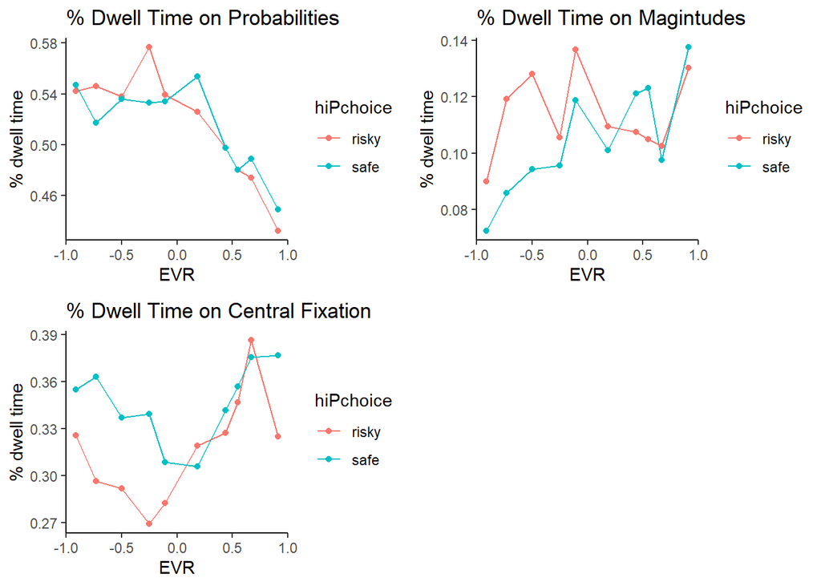

```r
safe_risky_gaze <- iareduced_choice %>%
  group_by(EVR, hiPchoice) %>%
  summarise(mean_p=mean(p_pt_DT), mean_m=mean(m_pt_DT), mean_f=mean(fx_pt_DT))

safe_risky_gaze$hiPchoice <- ifelse(safe_risky_gaze$hiPchoice==1,"safe","risky")

safe_risky_gaze_cues <- iareduced_choice %>%
  group_by(Cues, hiPchoice) %>%
  summarise(mean_p=mean(p_pt_DT), mean_m=mean(m_pt_DT), mean_f=mean(fx_pt_DT))

safe_risky_gazeUC <- iareduced_choiceUC %>%
  group_by(EVR, hiPchoice) %>%
  summarise(mean_p=mean(p_pt_DT), mean_m=mean(m_pt_DT), mean_f=mean(fx_pt_DT))

safe_risky_gazeUC$hiPchoice <- ifelse(safe_risky_gazeUC$hiPchoice==1,"safe","risky")

safe_risky_gazeC <- iareduced_choiceC %>%
  group_by(EVR, hiPchoice) %>%
  summarise(mean_p=mean(p_pt_DT), mean_m=mean(m_pt_DT), mean_f=mean(fx_pt_DT))

safe_risky_gazeC$hiPchoice <- ifelse(safe_risky_gazeC$hiPchoice==1,"safe","risky")

p1 <- ggplot(data=safe_risky_gaze, aes(x=EVR, y=mean_p, group=hiPchoice, color=hiPchoice)) +
  geom_line()+
  geom_point()+
  labs(title="% Dwell Time on Probabilities", y = "% dwell time")+
  theme_classic()

p2 <- ggplot(data=safe_risky_gaze, aes(x=EVR, y=mean_m, group=hiPchoice, color=hiPchoice)) +
  geom_line()+
  geom_point()+
  labs(title="% Dwell Time on Magintudes", y = "% dwell time")+
  theme_classic()

p3 <-ggplot(data=safe_risky_gaze, aes(x=EVR, y=mean_f, group=hiPchoice, color=hiPchoice)) +
  geom_line()+
  geom_point()+
  labs(title="% Dwell Time on Central Fixation", y = "% dwell time")+
  theme_classic()

p4 <- ggplot(data=safe_risky_gazeUC, aes(x=EVR, y=mean_p, group=hiPchoice, color=hiPchoice)) +
  geom_line()+
  geom_point()+
  labs(title="Uncued %DT on Probabilities", y = "% dwell time")+
  theme_classic()

p5 <- ggplot(data=safe_risky_gazeUC, aes(x=EVR, y=mean_m, group=hiPchoice, color=hiPchoice)) +
  geom_line()+
  geom_point()+
  labs(title="Uncued %DT on Magintudes", y = "% dwell time")+
  theme_classic()

p6 <-ggplot(data=safe_risky_gazeUC, aes(x=EVR, y=mean_f, group=hiPchoice, color=hiPchoice)) +
  geom_line()+
  geom_point()+
  labs(title="Uncued %DT on Central Fixation", y = "% dwell time")+
  theme_classic()

p7 <- ggplot(data=safe_risky_gazeC, aes(x=EVR, y=mean_p, group=hiPchoice, color=hiPchoice)) +
  geom_line()+
  geom_point()+
  labs(title="Cued %DT on Probabilities", y = "% dwell time")+
  theme_classic()

p8 <- ggplot(data=safe_risky_gazeC, aes(x=EVR, y=mean_m, group=hiPchoice, color=hiPchoice)) +
  geom_line()+
  geom_point()+
  labs(title="Cued %DT on Magintudes", y = "% dwell time")+
  theme_classic()

p9 <-ggplot(data=safe_risky_gazeC, aes(x=EVR, y=mean_f, group=hiPchoice, color=hiPchoice)) +
  geom_line()+
  geom_point()+
  labs(title="Cued %DT on Central Fixation", y = "% dwell time")+
  theme_classic()

grid.arrange(p1,p2,p3,nrow=2)
```

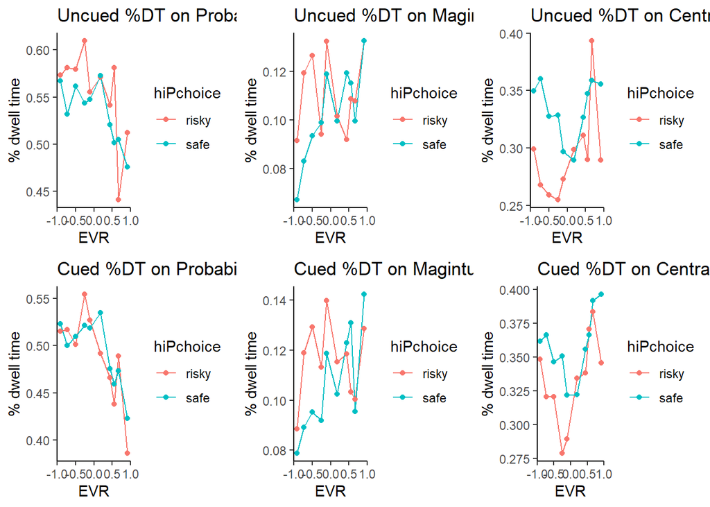

```r
grid.arrange(p4,p5,p6,p7,p8,p9,nrow=2)
```

# Does gaze dwelling on magnitudes predict riskier choice as a function of cues? There is a trend for an interaction, but overall, gaze fixations do not have mich predictive power over and above prospect characteristics.

```r
ml <- glmer(hiPchoice ~ m_pt_DT*Cues + EVR + order+ (Rep|subj), data=iareduced_choice, family = binomial, control = glmerControl(optimizer="bobyqa"))
summary(ml)
```

```
## Generalized linear mixed model fit by maximum likelihood (Laplace
##   Approximation) [glmerMod]
##  Family: binomial  ( logit )
## Formula: hiPchoice ~ m_pt_DT * Cues + EVR + order + (Rep | subj)
##    Data: iareduced_choice
## Control: glmerControl(optimizer = "bobyqa")
##
##      AIC      BIC   logLik deviance df.resid
##  10898.8  10966.1  -5440.4  10880.8    13091
##
## Scaled residuals:
##      Min       1Q   Median       3Q      Max
## -24.3962  -0.4338   0.1886   0.4335  17.3675
##
## Random effects:
##  Groups Name        Variance Std.Dev. Corr
##  subj   (Intercept) 2.37426  1.5409
##         Rep         0.01829  0.1352   -0.81
## Number of obs: 13100, groups:  subj, 131
##
## Fixed effects:
##              Estimate Std. Error z value Pr(>|z|)
## (Intercept)   1.44974    0.14214  10.200  < 2e-16 ***
## m_pt_DT      -3.03743    0.44705  -6.794 1.09e-11 ***
## Cues         -0.54260    0.18700  -2.902  0.00371 **
## EVR           3.11223    0.05609  55.482  < 2e-16 ***
## order         0.25981    0.17483   1.486  0.13726
## m_pt_DT:Cues  0.99420    0.59845   1.661  0.09665 .
## ---
## Signif. codes:  0 '***' 0.001 '**' 0.01 '*' 0.05 '.' 0.1 ' ' 1
##
## Correlation of Fixed Effects:
##             (Intr) m_p_DT Cues   EVR    order
## m_pt_DT     -0.362
## Cues        -0.688  0.256
## EVR          0.140 -0.135 -0.035
## order       -0.051  0.007  0.062  0.017
## m_pt_DT:Cus  0.263 -0.738 -0.352  0.023  0.007
```

```r
vif(ml)
```

```
##      m_pt_DT         Cues          EVR        order m_pt_DT:Cues
##     2.266146     1.147858     1.033617     1.005698     2.378283
```

Same analysis with ILR

```r
ml <- glmer(hiPchoice ~ Cues*ILR_m + EVR + order + (Rep|subj), data=iareduced_choice, family = binomial, control = glmerControl(optimizer="bobyqa"))
summary(ml)
```

```
## Generalized linear mixed model fit by maximum likelihood (Laplace
##   Approximation) [glmerMod]
##  Family: binomial  ( logit )
## Formula: hiPchoice ~ Cues * ILR_m + EVR + order + (Rep | subj)
##    Data: iareduced_choice
## Control: glmerControl(optimizer = "bobyqa")
##
##      AIC      BIC   logLik deviance df.resid
##  10888.9  10956.2  -5435.4  10870.9    13091
##
## Scaled residuals:
##      Min       1Q   Median       3Q      Max
## -24.8055  -0.4374   0.1870   0.4300  16.1551
##
## Random effects:
##  Groups Name        Variance Std.Dev. Corr
##  subj   (Intercept) 2.38683  1.5449
##         Rep         0.01841  0.1357   -0.81
## Number of obs: 13100, groups:  subj, 131
##
## Fixed effects:
##             Estimate Std. Error z value Pr(>|z|)
## (Intercept)  0.75333    0.14538   5.182  2.2e-07 ***
## Cues        -0.42906    0.19213  -2.233   0.0255 *
## ILR_m        0.14849    0.02516   5.902  3.6e-09 ***
## EVR          3.10858    0.05602  55.492  < 2e-16 ***
## order        0.25561    0.17424   1.467   0.1424
## Cues:ILR_m   0.00925    0.03399   0.272   0.7855
## ---
## Signif. codes:  0 '***' 0.001 '**' 0.01 '*' 0.05 '.' 0.1 ' ' 1
##
## Correlation of Fixed Effects:
##            (Intr) Cues   ILR_m  EVR    order
## Cues       -0.700
## ILR_m      -0.411  0.321
## EVR         0.049 -0.028  0.101
## order      -0.045  0.067 -0.005  0.017
## Cues:ILR_m  0.307 -0.419 -0.732  0.012 -0.009
```

```r
vif(ml)
```

```
##       Cues      ILR_m        EVR      order Cues:ILR_m
##   1.220326   2.212390   1.028438   1.005747   2.372317
```

```
ml1 = lmer(dwellTime ~ Cues*IAnum*STGT + (IAnum|subj), data=data)
summary(ml1)

ml1 = lmer(probs_ptDt ~ Cues*STGT + (IAnum|subj), data=PMF)
summary(ml1)

ml1 = lmer(mags_ptDt ~ Cues*STGT + (IAnum|subj), data=PMF)
summary(ml1)

ml1 = lmer(fix_ptDt ~ Cues*STGT + (IAnum|subj), data=PMF)
summary(ml1)
```